```python
import pandas as pd
import numpy as np
import matplotlib.pyplot as plt
import seaborn as sns
```

```python
df = pd.read_csv('Bank_Personal_Loan_Modelling.csv')
df.head()
```

|  | ID | Age | Experience | Income | ZIP Code | Family | CCAvg | Education | Mortgage | Personal Loan | Securities Account | CD Account | Online | CreditCard |
| --- | --- | --- | --- | --- | --- | --- | --- | --- | --- | --- | --- | --- | --- | --- |
| 0 | 1 | 25 | 1 | 49 | 91107 | 4 | 1.6 | 1 | 0 | 0 | 1 | 0 | 0 | 0 |
| 1 | 2 | 45 | 19 | 34 | 90089 | 3 | 1.5 | 1 | 0 | 0 | 1 | 0 | 0 | 0 |
| 2 | 3 | 39 | 15 | 11 | 94720 | 1 | 1.0 | 1 | 0 | 0 | 0 | 0 | 0 | 0 |
| 3 | 4 | 35 | 9 | 100 | 94112 | 1 | 2.7 | 2 | 0 | 0 | 0 | 0 | 0 | 0 |
| 4 | 5 | 35 | 8 | 45 | 91330 | 4 | 1.0 | 2 | 0 | 0 | 0 | 0 | 0 | 1 |

# We first find out the shape, and datatypes of the attributes in the dataframe

```python
print(df.shape)
print(df.columns)
```

```
(5000, 14)
Index(['ID', 'Age', 'Experience', 'Income', 'ZIP Code', 'Family', 'CCAvg',
       'Education', 'Mortgage', 'Personal Loan', 'Securities Account',
       'CD Account', 'Online', 'CreditCard'],
      dtype='object')
```

```python
print(df.info())
```

```
<class 'pandas.core.frame.DataFrame'>
RangeIndex: 5000 entries, 0 to 4999
Data columns (total 14 columns):
ID                    5000 non-null int64
Age                   5000 non-null int64
Experience            5000 non-null int64
Income                5000 non-null int64
ZIP Code              5000 non-null int64
Family                5000 non-null int64
CCAvg                 5000 non-null float64
Education             5000 non-null int64
Mortgage              5000 non-null int64
Personal Loan         5000 non-null int64
Securities Account    5000 non-null int64
CD Account            5000 non-null int64
Online                5000 non-null int64
CreditCard            5000 non-null int64
dtypes: float64(1), int64(13)
memory usage: 547.0 KB
None
```

```python
df.drop('ID', axis = 1, inplace = True) # ID is of no use for EDA in this dataset
```

```python
#Finding null values
df.isnull().sum()
```

```
Age                   0
Experience            0
Income                0
ZIP Code              0
Family                0
CCAvg                 0
Education             0
Mortgage              0
Personal Loan         0
Securities Account    0
CD Account            0
Online                0
CreditCard            0
dtype: int64
```

No null value is there in dataframe

```python
df.columns
```

```
Index(['Age', 'Experience', 'Income', 'ZIP Code', 'Family', 'CCAvg',
       'Education', 'Mortgage', 'Personal Loan', 'Securities Account',
       'CD Account', 'Online', 'CreditCard'],
      dtype='object')
```

```python
df.describe().transpose()
```

|  | count | mean | std | min | 25% | 50% | 75% | max |
| --- | --- | --- | --- | --- | --- | --- | --- | --- |
| Age | 5000.0 | 45.338400 | 11.463166 | 23.0 | 35.0 | 45.0 | 55.0 | 67.0 |
| Experience | 5000.0 | 20.104600 | 11.467954 | -3.0 | 10.0 | 20.0 | 30.0 | 43.0 |
| Income | 5000.0 | 73.774200 | 46.033729 | 8.0 | 39.0 | 64.0 | 98.0 | 224.0 |
| ZIP Code | 5000.0 | 93152.503000 | 2121.852197 | 9307.0 | 91911.0 | 93437.0 | 94608.0 | 96651.0 |
| Family | 5000.0 | 2.396400 | 1.147663 | 1.0 | 1.0 | 2.0 | 3.0 | 4.0 |
| CCAvg | 5000.0 | 1.937938 | 1.747659 | 0.0 | 0.7 | 1.5 | 2.5 | 10.0 |
| Education | 5000.0 | 1.881000 | 0.839869 | 1.0 | 1.0 | 2.0 | 3.0 | 3.0 |
| Mortgage | 5000.0 | 56.498800 | 101.713802 | 0.0 | 0.0 | 0.0 | 101.0 | 635.0 |
| Personal Loan | 5000.0 | 0.096000 | 0.294621 | 0.0 | 0.0 | 0.0 | 0.0 | 1.0 |
| Securities Account | 5000.0 | 0.104400 | 0.305809 | 0.0 | 0.0 | 0.0 | 0.0 | 1.0 |
| CD Account | 5000.0 | 0.060400 | 0.238250 | 0.0 | 0.0 | 0.0 | 0.0 | 1.0 |
| Online | 5000.0 | 0.596800 | 0.490589 | 0.0 | 0.0 | 1.0 | 1.0 | 1.0 |
| CreditCard | 5000.0 | 0.294000 | 0.455637 | 0.0 | 0.0 | 0.0 | 1.0 | 1.0 |

# 2. Study the data distribution in each attribute, share your findings (15 marks)

```python
num_cols = ['Age',
 'Experience',
 'Income',
 'CCAvg',
 'Mortgage']
```

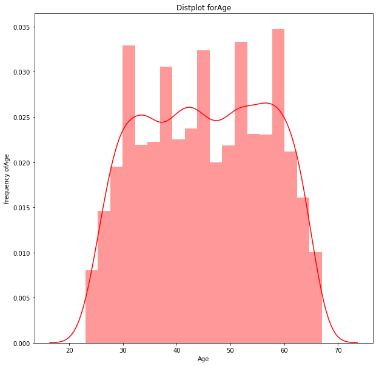

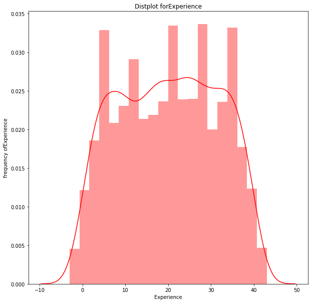

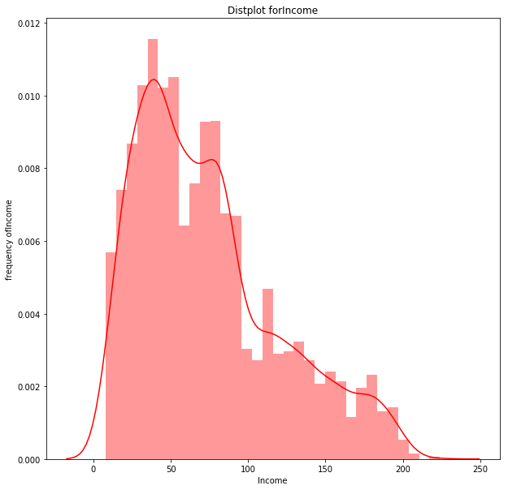

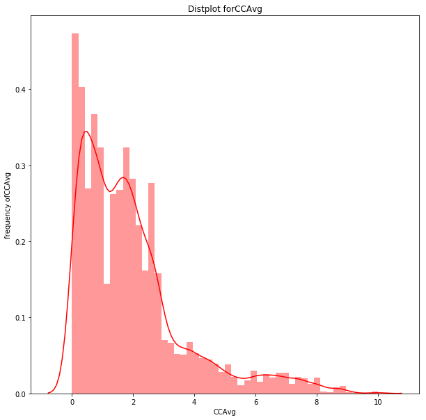

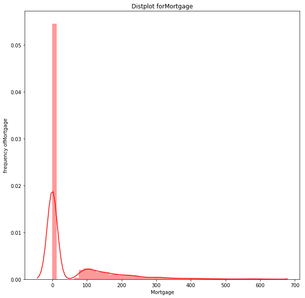

```python
for num in num_cols:
    plt.figure(figsize=(10,10))
    sns.distplot(df[num], color = 'red')
    plt.xlabel(num)
    plt.ylabel('frequency of' +num)
    plt.title('Distplot for'+num)
    plt.savefig("Distplot/distplot for {}".format(num))
```

Inference from age: Bank does not take ages of people below 20 into account Inference from income: Max people have an annual income of about $(30000-50000) Inference from CCAvg: Max people have a credit card avg spending of about $(0-10000) Inference from MortGage: Max people have a Value of house mortgage of about $(0-10000)

```python
cat_cols = ['Personal Loan', 'Securities Account',
       'CD Account', 'Online', 'CreditCard', "Family", "Education"]
```

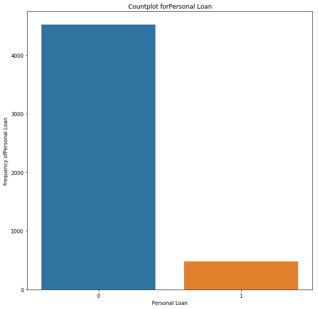

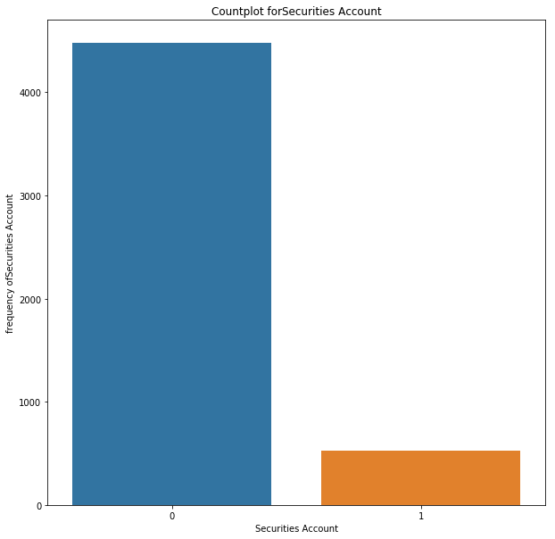

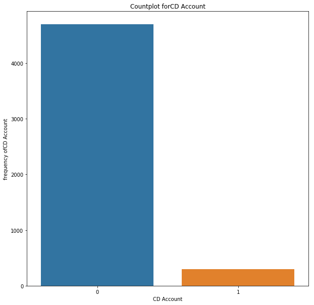

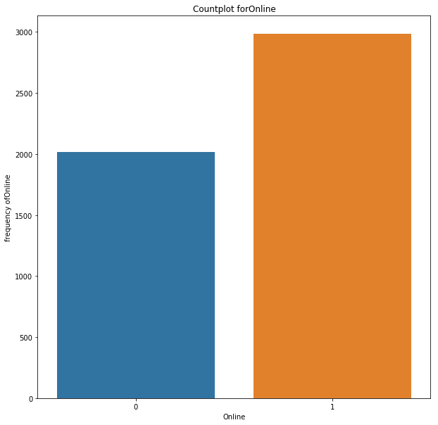

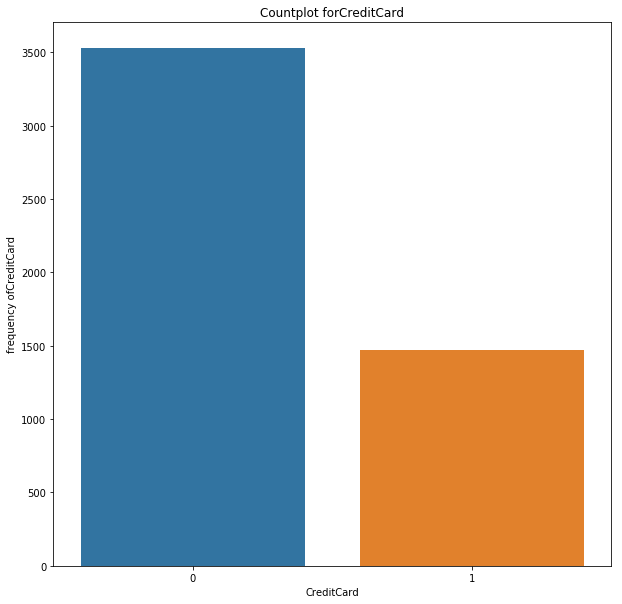

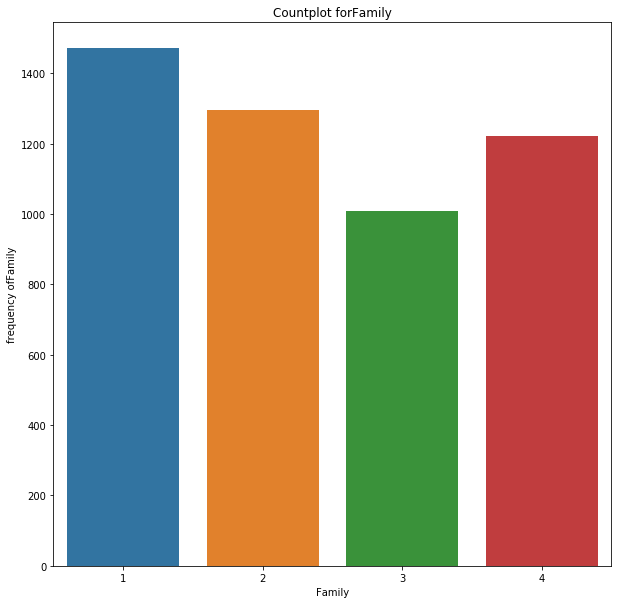

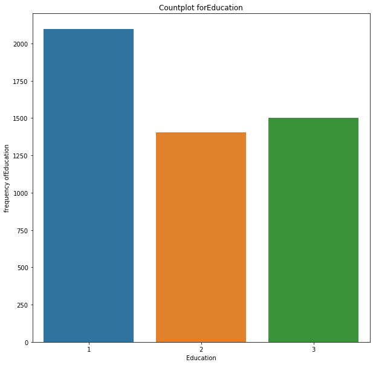

```python
for cat in cat_cols:

    plt.figure(figsize=(10,10))
    sns.countplot(df[cat])
    plt.xlabel(cat)
    plt.ylabel('frequency of' +cat)
    plt.title('Countplot for' +cat)
    plt.savefig("Countplot/countplot for {}".format(cat))
```

```python
for cat in cat_cols:
    print("data dist for" + cat)
    print(df[cat].value_counts()/df[cat].count()*100)
```

```
data dist forPersonal Loan
0    90.4
1     9.6
Name: Personal Loan, dtype: float64
data dist forSecurities Account
0    89.56
1    10.44
Name: Securities Account, dtype: float64
data dist forCD Account
0    93.96
1     6.04
Name: CD Account, dtype: float64
data dist forOnline
1    59.68
0    40.32
Name: Online, dtype: float64
data dist forCreditCard
0    70.6
1    29.4
Name: CreditCard, dtype: float64
data dist forFamily
1    29.44
2    25.92
4    24.44
3    20.20
Name: Family, dtype: float64
data dist forEducation
1    41.92
3    30.02
2    28.06
Name: Education, dtype: float64
```

```python
    plt.figure(figsize = (15,10))
    sns.pairplot(df)

    plt.title('Pairplot')
    plt.savefig("Pair_plot/pairplot.jpg", dpi =100, bbox_tight = True)
    plt.xticks(rotation = 45)
```

[output not shown]

```python
plt.figure(figsize = (10,10))
sns.heatmap(df, annot = True)
plt.savefig('heatmap')
```

[output not shown]

```python
columns = ['Age', 'Experience', 'Income', 'Family', 'CCAvg',
       'Education', 'Mortgage']
```

```python
for num in columns:
    plt.figure(figsize =(10,10))
    sns.barplot(x = 'Personal Loan', y= num , data = df, color = 'blue')
    plt.title("barplot between personal loan and {}".format(num) )
    plt.xlabel('Personal Loan')
    plt.ylabel(num)
    plt.savefig('Barplot/barplot for {}'.format(num))
```

[output not shown]

```python
df[df['Personal Loan'] == 1]['Mortgage'].mean()
```

[output not shown]

```python
df[df['Personal Loan'] == 1]['CCAvg'].mean()
```

[output not shown]

```python
df[df['Personal Loan'] == 1]['Income'].mean()
```

[output not shown]

```python
sns.boxplot(x= 'Personal Loan', y = 'Experience', hue = 'Family', data = df)
```

[output not shown]

```python
cat_cols = ['Family', 'Education', 'Securities Account',
       'CD Account', 'Online', 'CreditCard']
```

Here we are calculating the percentage of different categories in the following columns for people who have opted for personal loan

```python
for col in cat_cols:
    print(col)
    print(df[df['Personal Loan']==1][col].value_counts()/df[df['Personal Loan']==1][col].count()*100)
```

[output not shown]

# 3. Get the target column distribution. Your comments (5 marks)

Here the target column is Personal Loan

```python
print(df['Personal Loan'].value_counts()/df['Personal Loan'].count()*100)
```

[output not shown]

So 9.6 % of the customer has accepted the personal Loan. Distributions of Personal Loans with other features are given in the previous question and the effect of features on target column can be derived from the results

```python
df['Personal Loan'].value_counts()
```

[output not shown]

```python
sns.countplot(df['Personal Loan'], palette = 'rainbow')
```

[output not shown]

We find that no of samples of 0 in Personal loans is far greater than that of 1. So we trying to balance the 2 classes by undersampling

# UNDERSAMPLING (Data Cleaning)

```python
minority_class_length = len(df[df['Personal Loan']==1])
```

```python
majority_class_indices =df[df["Personal Loan"]==0].index
```

```python
random_maj_class_indices = np.random.choice(majority_class_indices, minority_class_length, replace = False)
```

```python
minority_class_index = df[df['Personal Loan']==1].index
```

```python
under_sample_index = np.concatenate([minority_class_index, random_maj_class_indices])
```

```python
new_df = df.loc[under_sample_index]
```

```python
new_df.shape
```

```
(960, 13)
```

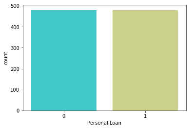

```python
sns.countplot(new_df['Personal Loan'], palette = 'rainbow')
```

So we find that bothe the classes have almost equal no of records

# 4. Split the data into training and test set in the ratio of 70:30 respectively (5 marks)

```python
# splitting of features and target

X= new_df.drop(['Personal Loan','ZIP Code' ], axis = 1)
y = new_df['Personal Loan']
```

```python
from sklearn.model_selection import train_test_split

X_train, X_test, y_train, y_test = train_test_split(X,y, test_size = .3, random_state = 1)
```

# 5) Use different classification models (Logistic, K-NN and Naïve Bayes) to predict the likelihood of a customer buying personal loans (15 marks)

We are first implementing the Logistic regression model

# LOGISTIC REGRESSION

```python
from sklearn.linear_model import LogisticRegression

log_model = LogisticRegression()

log_model.fit(X_train, y_train) #we fit the model with train data
```

```
LogisticRegression(C=1.0, class_weight=None, dual=False, fit_intercept=True,
          intercept_scaling=1, max_iter=100, multi_class='warn',
          n_jobs=None, penalty='l2', random_state=None, solver='warn',
          tol=0.0001, verbose=0, warm_start=False)
```

```python
pred_train = log_model.predict(X_train) # these are the predictions
pred_test = log_model.predict(X_test)
```

```python
print(log_model.coef_)
print(log_model.intercept_) # These are the intercepts and coeff of this model
```

```
[[-3.80683271e-01  3.91968859e-01  5.22541525e-02  5.93686020e-01
   2.28384732e-01  1.34334668e+00 -7.18802654e-04 -1.18760604e-02
   2.45512331e+00 -2.26809657e-01 -7.23366653e-01]]
[-0.91790226]
```

```python
from sklearn.metrics import *

print(accuracy_score(y_train, pred_train))
print(accuracy_score(y_test, pred_test))
```

```
0.8988095238095238
0.8923611111111112
```

The accuracy is good for both train and test data Lets find the other parameters in the metrics

```python
print(classification_report(y_train, pred_train))
print(classification_report(y_test, pred_test))
```

```
              precision    recall  f1-score   support

           0       0.90      0.89      0.90       332
           1       0.90      0.90      0.90       340

   micro avg       0.90      0.90      0.90       672
   macro avg       0.90      0.90      0.90       672
weighted avg       0.90      0.90      0.90       672

              precision    recall  f1-score   support

           0       0.88      0.92      0.90       148
           1       0.91      0.86      0.89       140

   micro avg       0.89      0.89      0.89       288
   macro avg       0.89      0.89      0.89       288
weighted avg       0.89      0.89      0.89       288
```

1) Precission, Recall, f1-score have values nearby 90% for both test and train data for 0 (if 0 is +ve)

```python
tpr, fpr , threshold = roc_curve(y_test, log_model.predict_proba(X_test)[:,1])
```

```python
def roc_curve(tpr, fpr, c='r', label = "ROC"):
    plt.figure(figsize=(8,8))
    plt.plot(tpr, fpr, color = c, linewidth = 3, label = label)
    plt.xlabel('fpr')
    plt.ylabel('tpr')
    plt.plot([0, 1], [0, 1],'r--')
    plt.xlim([0.0, 1.0])
    plt.ylim([0.0, 1.0])
    plt.title('Receiver operating characteristic')
    plt.savefig('Roc_curve_LogReg')
```

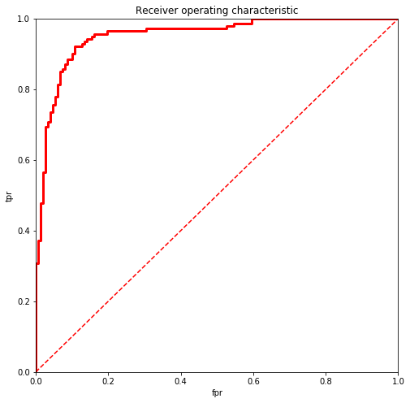

```python
roc_curve(tpr, fpr)
```

```python
Area_Under_curve = roc_auc_score(y_test, log_model.predict_proba(X_test)[:,1])
print(Area_Under_curve)
```

```
0.9528957528957529
```

We find that the area under the curve is a very good score. So we have evaluated the logistic regression model for classification. Lets compare this to other models.

# Naive Bayes Algorithm

```python
from sklearn.naive_bayes import GaussianNB

model_naive = GaussianNB()

model_naive.fit(X_train, y_train)
```

```
GaussianNB(priors=None, var_smoothing=1e-09)
```

```python
pred_train_2 = model_naive.predict(X_train) # these are the predictions
pred_test_2 = model_naive.predict(X_test)
```

```python
print(accuracy_score(y_train, pred_train_2))
print(accuracy_score(y_test, pred_test_2))
```

```
0.8422619047619048
0.8368055555555556
```

The accuracy is good for both train and test data but not better than Logistic Regression model Lets find the other parameters in the metrics

```python
print(classification_report(y_train, pred_train_2))
print(classification_report(y_test, pred_test_2))
```

```
              precision    recall  f1-score   support

           0       0.81      0.88      0.85       332
           1       0.88      0.80      0.84       340

   micro avg       0.84      0.84      0.84       672
   macro avg       0.84      0.84      0.84       672
weighted avg       0.84      0.84      0.84       672

              precision    recall  f1-score   support

           0       0.81      0.90      0.85       148
           1       0.88      0.77      0.82       140

   micro avg       0.84      0.84      0.84       288
   macro avg       0.84      0.84      0.84       288
weighted avg       0.84      0.84      0.84       288
```

The other metrics parameters like precission, recall, f1-score are good for 0 and 1 lets move to other parameters

```python
from sklearn.metrics import roc_auc_score
from sklearn.metrics import roc_curve
```

```python
tpr, fpr, thresholds = roc_curve(y_test, model_naive.predict_proba(X_test)[:,1])
```

```python
def roc_curve(tpr, fpr, c='g', label = "ROC"):
    plt.figure(figsize=(8,8))
    plt.plot(tpr, fpr, color = c, linewidth = 3, label = label)
    plt.xlabel('fpr')
    plt.ylabel('tpr')
    plt.plot([0, 1], [0, 1],'b--')
    plt.xlim([0.0, 1.0])
    plt.ylim([0.0, 1.0])
    plt.title('Receiver operating characteristic')
    plt.savefig('Roc_curve_naive')
```

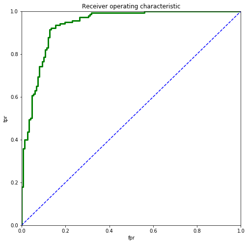

```python
roc_curve(tpr, fpr)
```

```python
Area_Under_curve = roc_auc_score(y_test, model_naive.predict_proba(X_test)[:,1])
print(Area_Under_curve)
```

```
0.938561776061776
```

The Area Under Curve is pretty good for Naive Bayes model. Let us compare other classification models with this model

# KNeighbors Classifier

```python
from sklearn.neighbors import KNeighborsClassifier
score_train = []
score_test= []
```

We collect the accuracy score of train and test data for odd values of n in range(1,50) and store it in 2 lists

```python
X_test.shape
```

```
(288, 11)
```

```python
no_of_k_values_to_be_taken = 288**0.5
no_of_k_values_to_be_taken
```

```
16.97056274847714
```

```python
k = list(range(1,50)) #We iterate the list to 71

n = list(filter(lambda x : x%2!= 0, k))
```

```python
for i in n:
    model = KNeighborsClassifier(n_neighbors = i)
    model.fit(X_train, y_train)
    print('value of k is {}'.format(i))
    a = accuracy_score(y_train, model.predict(X_train))
    print('test accuracy')
    print(accuracy_score(y_test, model.predict(X_test)))
    b = accuracy_score(y_test, model.predict(X_test))
    score_train.append(a)
    score_test.append(b)
```

```
value of k is 1
test accuracy
0.8263888888888888
value of k is 3
test accuracy
0.8576388888888888
value of k is 5
test accuracy
0.8611111111111112
value of k is 7
test accuracy
0.8576388888888888
value of k is 9
test accuracy
0.8645833333333334
value of k is 11
test accuracy
0.8715277777777778
value of k is 13
test accuracy
0.8645833333333334
value of k is 15
test accuracy
0.8645833333333334
value of k is 17
test accuracy
0.8715277777777778
value of k is 19
test accuracy
0.875
value of k is 21
test accuracy
0.8645833333333334
value of k is 23
test accuracy
0.8645833333333334
value of k is 25
test accuracy
0.8680555555555556
value of k is 27
```

[output cut: 20 more lines]

```
value of k is 41
test accuracy
0.8645833333333334
value of k is 43
test accuracy
0.8611111111111112
value of k is 45
test accuracy
0.8611111111111112
value of k is 47
test accuracy
0.8611111111111112
value of k is 49
test accuracy
0.8611111111111112
```

```python
for i in n:
    model = KNeighborsClassifier(n_neighbors = i)
    model.fit(X_train, y_train)
    print('value of k is {}'.format(i))
    print(accuracy_score(y_train, model.predict(X_train)))
```

```
value of k is 1
1.0
value of k is 3
0.9166666666666666
value of k is 5
0.8958333333333334
value of k is 7
0.8898809523809523
value of k is 9
0.8869047619047619
value of k is 11
0.8869047619047619
value of k is 13
0.8854166666666666
value of k is 15
0.8839285714285714
value of k is 17
0.8794642857142857
value of k is 19
0.8779761904761905
value of k is 21
0.8735119047619048
value of k is 23
0.8720238095238095
value of k is 25
0.8735119047619048
value of k is 27
0.8764880952380952
value of k is 29
0.8764880952380952
value of k is 31
0.8735119047619048
value of k is 33
0.8720238095238095
value of k is 35
0.875
value of k is 37
0.8720238095238095
value of k is 39
0.8735119047619048
value of k is 41
0.8735119047619048
value of k is 43
0.875
value of k is 45
0.875
value of k is 47
0.8720238095238095
value of k is 49
0.8690476190476191
```

```python
max(score_test) # max accuracy
```

```
0.875
```

```python
n[score_test.index(max(score_test))]  #n value for  max test accuracy
```

```
19
```

So max accuracy for test data is for n = 19. Let us calculate other parameters# Below we are calculating the Area under curve for each n value and storing it in a list

```python
auc = []
```

```python
for i in n:
    model = KNeighborsClassifier(n_neighbors = i)
    model.fit(X_train, y_train)
    print('value of k is {}'.format(i))
    Auc = roc_auc_score(y_test, model.predict_proba(X_test)[:,1])
    print(Auc)
    auc.append(Auc)
```

```
value of k is 1
0.8266409266409267
value of k is 3
0.8952944015444015
value of k is 5
0.9022683397683398
value of k is 7
0.9099420849420851
value of k is 9
0.9170366795366796
value of k is 11
0.9185328185328185
value of k is 13
0.9203426640926642
value of k is 15
0.9185569498069498
value of k is 17
0.9259169884169886
value of k is 19
0.9251930501930503
value of k is 21
0.9262789575289576
value of k is 23
0.9252171814671813
value of k is 25
0.9225627413127413
value of k is 27
0.9241795366795367
value of k is 29
0.9238175675675675
value of k is 31
0.9243243243243243
value of k is 33
0.9244449806949807
value of k is 35
0.9221283783783784
value of k is 37
0.9194498069498069
value of k is 39
0.9180501930501931
value of k is 41
0.9170608108108107
value of k is 43
0.9193050193050193
value of k is 45
0.9185810810810812
value of k is 47
0.9194739382239382
value of k is 49
0.917519305019305
```

```python
print(max(auc))
print(n[auc.index(max(auc))])
```

```
0.9262789575289576
21
```

So for k = 21 , the Area under curve has the largest value. So lets draw the receiver operating characteristic curve

```python
model_new = KNeighborsClassifier(n_neighbors = 21, weights = 'distance' )
model_new.fit(X_train, y_train)
```

```
KNeighborsClassifier(algorithm='auto', leaf_size=30, metric='minkowski',
           metric_params=None, n_jobs=None, n_neighbors=21, p=2,
           weights='distance')
```

[output not shown]

[figure not shown]

```python
tpr, fpr, thresholds = roc_curve(y_test, model_new.predict_proba(X_test)[:,1])
```

```python
def roc_curve(tpr, fpr, c = 'r', label = "ROC curve"):
    plt.figure(figsize = (10,8))
    plt.plot(tpr, fpr, color = c, linewidth = 3, label = label)
    plt.xlim([0.0, 1.0])
    plt.ylim([0.0 , 1.0])
    plt.plot([0, 1], [0, 1],'g--')
    plt.title('ROC')

    plt.xlabel('fpr')
    plt.ylabel('tpr')
    plt.savefig('ROC_KNN')
```

[figure not shown]

```python
roc_curve(tpr, fpr)
```

```python
 Auc = roc_auc_score(y_test, model.predict_proba(X_test)[:,1])
 print(Auc)
```

```
0.917519305019305
```

We prepare the classification report

```python
model_n = KNeighborsClassifier(n_neighbors = 7, weights = 'distance' )
model_n.fit(X_train, y_train)
```

```
KNeighborsClassifier(algorithm='auto', leaf_size=30, metric='minkowski',
           metric_params=None, n_jobs=None, n_neighbors=7, p=2,
           weights='distance')
```

```python
print(classification_report(y_train, model_new.predict(X_train)))
print(classification_report(y_test, model_new.predict(X_test)))
```

```
              precision    recall  f1-score   support

           0       1.00      1.00      1.00       332
           1       1.00      1.00      1.00       340

   micro avg       1.00      1.00      1.00       672
   macro avg       1.00      1.00      1.00       672
weighted avg       1.00      1.00      1.00       672

              precision    recall  f1-score   support

           0       0.90      0.82      0.86       148
           1       0.83      0.91      0.87       140

   micro avg       0.86      0.86      0.86       288
   macro avg       0.87      0.87      0.86       288
weighted avg       0.87      0.86      0.86       288
```

# Support Vector Classifier

We use the SVC and check the performance of the modEL

```python
from sklearn.svm import SVC
```

```python
CLF = SVC(gamma = 0.1, C = 5, probability= True)
```

```python
CLF.fit(X_train, y_train)
```

```
SVC(C=5, cache_size=200, class_weight=None, coef0=0.0,
  decision_function_shape='ovr', degree=3, gamma=0.1, kernel='rbf',
  max_iter=-1, probability=True, random_state=None, shrinking=True,
  tol=0.001, verbose=False)
```

```python
print(accuracy_score(y_train, CLF.predict(X_train)))
print(accuracy_score(y_test, CLF.predict(X_test)))
```

```
1.0
0.7430555555555556
```

So we find that the test accuracy is poor. Lets find the other parameters

```python
print(classification_report(y_train, CLF.predict(X_train)))
print(classification_report(y_test, CLF.predict(X_test)))
```

```
              precision    recall  f1-score   support

           0       1.00      1.00      1.00       332
           1       1.00      1.00      1.00       340

   micro avg       1.00      1.00      1.00       672
   macro avg       1.00      1.00      1.00       672
weighted avg       1.00      1.00      1.00       672

              precision    recall  f1-score   support

           0       0.88      0.58      0.70       148
           1       0.67      0.91      0.78       140

   micro avg       0.74      0.74      0.74       288
   macro avg       0.78      0.75      0.74       288
weighted avg       0.78      0.74      0.74       288
```

It seems to be a overfitted model. all parameters are average

[output not shown]

[figure not shown]

```python
tpr, fpr, thresholds = roc_curve(y_test, CLF.predict_proba(X_test)[:,1])
```

```python
def roc_curve(tpr, fpr, c = 'r', label = "ROC curve"):
    plt.figure(figsize = (10,8))
    plt.plot(tpr, fpr, color = c, linewidth = 3, label = label)
    plt.xlim([0.0, 1.0])
    plt.ylim([0.0 , 1.0])
    plt.plot([0, 1], [0, 1],'g--')
    plt.title('ROC')

    plt.xlabel('fpr')
    plt.ylabel('tpr')
    plt.savefig('ROC_SVC')
```

[figure not shown]

```python
roc_curve(tpr, fpr)
```

```python
print("area under curve is {}".format(roc_auc_score(y_test, CLF.predict_proba(X_test)[:,1])))
```

```
area under curve is 0.8488899613899614
```

The area under the curve is good for this model

# Decision tree

```python
from sklearn.tree import DecisionTreeClassifier
dtree = DecisionTreeClassifier(criterion='gini',
    splitter='best',
    max_depth= 4)
```

```python
dtree.fit(X_train, y_train)
```

```
DecisionTreeClassifier(class_weight=None, criterion='gini', max_depth=4,
            max_features=None, max_leaf_nodes=None,
            min_impurity_decrease=0.0, min_impurity_split=None,
            min_samples_leaf=1, min_samples_split=2,
            min_weight_fraction_leaf=0.0, presort=False, random_state=None,
            splitter='best')
```

```python
from sklearn.metrics import *
```

```python
print(accuracy_score(y_train , dtree.predict(X_train)))
print(accuracy_score(y_test , dtree.predict(X_test)))
```

```
0.9672619047619048
0.9652777777777778
```

```python
print(classification_report(y_train , dtree.predict(X_train)))
print(classification_report(y_test, dtree.predict(X_test)))
```

```
              precision    recall  f1-score   support

           0       0.97      0.96      0.97       332
           1       0.96      0.97      0.97       340

   micro avg       0.97      0.97      0.97       672
   macro avg       0.97      0.97      0.97       672
weighted avg       0.97      0.97      0.97       672

              precision    recall  f1-score   support

           0       0.98      0.95      0.97       148
           1       0.95      0.98      0.96       140

   micro avg       0.97      0.97      0.97       288
   macro avg       0.97      0.97      0.97       288
weighted avg       0.97      0.97      0.97       288
```

The metrics parameters have a really good score. Lets plot the ROC curve.

```python
tpr, fpr, thresholds = roc_curve(y_test, dtree.predict_proba(X_test)[:,1])
```

```python
def roc_curve(tpr, fpr, c = 'r', label = "ROC curve"):
    plt.figure(figsize = (10,8))
    plt.plot(tpr, fpr, color = c, linewidth = 3, label = label)
    plt.xlim([0.0, 1.0])
    plt.ylim([0.0 , 1.0])
    plt.plot([0, 1], [0, 1],'g--')
    plt.title('ROC')

    plt.xlabel('fpr')
    plt.ylabel('tpr')
    plt.savefig('ROC_Decisiontree')
```

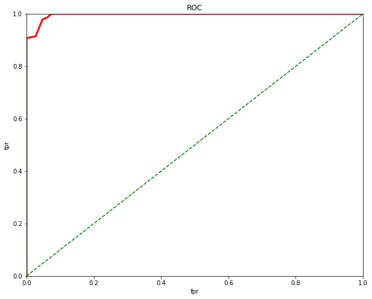

```python
roc_curve(tpr, fpr)
```

```python
print("area under curve is {}".format(roc_auc_score(y_test, dtree.predict_proba(X_test)[:,1])))
```

```
area under curve is 0.9961631274131274
```

We find the area under curve is is extremely good

# 6. Print the confusion matrix for all the above models

# LOGISTIC REGRESSION

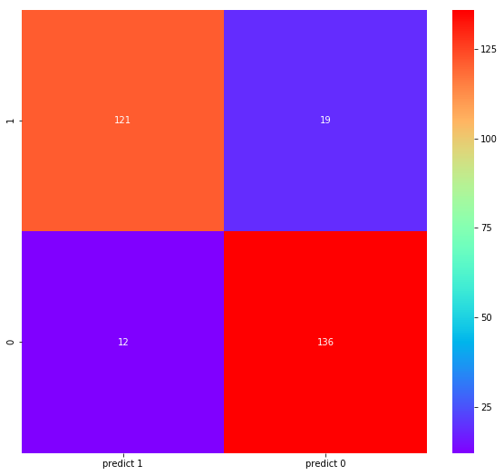

```python
c = confusion_matrix(y_test, pred_test, labels = [1,0])
conf_df = pd.DataFrame(c, index = [i for i in ["1","0"]], columns= ['predict 1', 'predict 0'])
plt.figure(figsize = (10,9))
sns.heatmap(conf_df, annot = True, fmt = 'g', cmap = 'rainbow')
plt.savefig('Conf_matrix for logreg')
```

# NAIVE BAYES

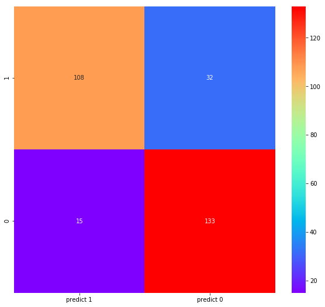

```python
c_1 = confusion_matrix(y_test, pred_test_2, labels = [1,0])
conf_df_2 = pd.DataFrame(c_1, index = [i for i in ["1","0"]], columns= ['predict 1', 'predict 0'])
plt.figure(figsize = (10,9))
sns.heatmap(conf_df_2, annot = True, fmt = 'g', cmap = 'rainbow')
plt.savefig('Conf_matrix for NAIVE-BAYES')
```

# KNearestNeighbors

```python
model_new = KNeighborsClassifier(n_neighbors = 3, weights = 'distance' )
model_new.fit(X_train, y_train)
p = model_new.predict(X_test)
```

[figure not shown]

```python
c_2 = confusion_matrix(y_test, p, labels = [1,0])
conf_df_3 = pd.DataFrame(c_1, index = [i for i in ["1","0"]], columns= ['predict 1', 'predict 0'])
plt.figure(figsize = (10,9))
sns.heatmap(conf_df_3, annot = True, fmt = 'g', cmap = 'rainbow')
plt.savefig('Conf_matrix for KNeighbors')
```

# SUPPORT VECTOR CLASSIFIER

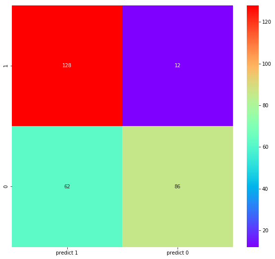

```python
c_3 = confusion_matrix(y_test, CLF.predict(X_test), labels = [1,0])
conf_df_4 = pd.DataFrame(c_3, index = [i for i in ["1","0"]], columns= ['predict 1', 'predict 0'])
plt.figure(figsize = (10,9))
sns.heatmap(conf_df_4, annot = True, fmt = 'g', cmap = 'rainbow')
plt.savefig('Conf_matrix for SVC')
```

# DECISION TREE CONFUSION MATRIX

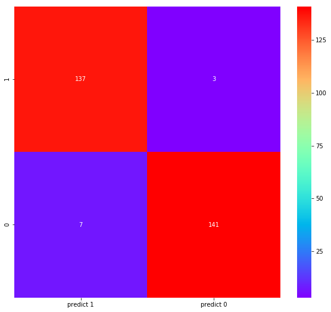

```python
c_5 = confusion_matrix(y_test, dtree.predict(X_test), labels = [1,0])
conf_df_4 = pd.DataFrame(c_5, index = [i for i in ["1","0"]], columns= ['predict 1', 'predict 0'])
plt.figure(figsize = (10,9))
sns.heatmap(conf_df_4, annot = True, fmt = 'g', cmap = 'rainbow')
plt.savefig('Conf_matrix for DecisionTree')
```

# 7) Give your reasoning on which is the best model in this case and why it performs better? (5 marks)

We find that the accuracy, precission, f1-score, recall f1-score are all highest for the "Decision tree classifier model". The Area Under Curve is also highest for DecisionTreeClassifier model . Higher the Area Under Roc Curve , better is the model performance. All metric parameters are highest for DecisionTreeClassifier

# So DecisionTreeClassifier is the best model in terms of performance for predicting the likelihood of a liability customer buying personal loans.